# DATA 603 Project Presentation

Mark Dodd, Michael Ellsworth, Dustin Tang, Raymond Wong

2019-12-03

## Descriptive Statistics

Each descriptive statistic considered in both the logistic and multiple linear regression models are described below. All variables are numeric values and are either a whole number or represented as a percentage.

| Hockey Stat Abbrev. | Hockey Stat. Name | Description | Relation |
| --- | --- | --- | --- |
| AvAge | Average Age | Average Age of the hockey team | Lower age means a youger team |
| W | Wins | Number of Wins for a season | More wins in a season better the team |
| L (Losses) | Losses | Number of Losses for a season | More losses in a season the worse the team |
| OL (Overtime Losses) | Overtime Losses | Number of Overtime Losses for a season | More Overtime Losses in a season the worse the team but these losses aren’t as bad as regular losses |
| PTS (Points) | Points per season | The number of points for a team for a season | More points in a season better the team |
| GF (Goals For Team A) | Goals for Team A | Number of goals a team scores for a season | More goals in a season better the team |
| GA (Goals Against Team A | Goals Againist Team A | Number of goals a team lets in for a season | More goals againist in a season better the team |
| GD (GF - GA) | Goal Differential | The difference of goals for a team. The number of goals for minus the number of goals againist | The higher the difference the better the team |
| SOW | Shootout wins | Number of wins for a team in the shootout | More SOW means the team is better at the Shootout |
| SOL | Shootout Losses | Number of loses for a team in the shootout | More SOL means the team is worse at the Shootout |
| SRS | Simple Rating System | Rating for Goal Differential and Strength of Schedule | Higher SRS means better the team |
| SOS | Strength of Scehdule | Measurement of the opponent in the standings | Lower sos means the opponent are not good |
| TG/G | Total goals = (GF+GA) per game | Total goals = (GF+GA) per game | The higher TG/G means the more goals per game |
| EVGF | Even Strength Goals For | Even Strength Goals For a team per season | Higher EVGF means the team is better at even strength |
| EVGA | Even Strength Goals Against | Even Strength Goals Against per season | Lower EVGA means the team is better at even strength |
| PD (Penalty Differential) | Penalty Minutes For - Penalty Minutes againist per game in a season | The difference of Penalty for - Penalty againist per game in a season | The higher Penalty Differential means the team takes more penalties |
| SD (Shot Differential) | Shots For - Shots againist per game in a season | Shots For - Shots againist per game in a season | The higher Shots Differential means the team takes more shots than they give up |
| PDO | Shooting % + Save % at Even Strength | Shooting % + Save % at Even Strength | Higher pdo means the better the team at Even Strength |
| CF% | Corsi For % at 5 on 5 | Percentage of any shot attempt (goals, shots on net, misses and blocked shots) | The higher cf% means the team is shotting more than their opponents. |
| FF% - Percentage of any shot attempt (goals, shots on net, misses) | Fenwick For % at 5 on 5 FF / (FF + FA) | Above 50% means the team was controlling the puck more often than not with this player on the ice in this situation. This doesn’t count blocked shots | The higher FF% means the team is shooting more than their opponents. |
| xGF | Expected Goals For | Expected Goals For’ given where shots came from, for and against, while this player was on the ice at even strength. It’s based on where the shots are coming from, compared to the league-wide shooting… | The higher xGF the more goals a team is expected to score for a game |
| xGA | Expected Goals Against | Expected Goals Against’ given where shots came from, for and against, while this player was on the ice at even strength. It’s based on where the shots are coming from, compared to the league-wide shoo… | The lower xGA the more goals a team is expected to let in for a game |
| SCF% | Percentage Scoring Chances for | Percentage of scoring chances in this team’s favor | Higher scf% means a team has more scoring chances |
| HDF% | High Danger Scoring Chances For Percentage | Percentage of high-danger scoring chances in this team’s favor | Higher HDF% means a team has more scoring chances |

## Multiple Linear Regression Model for Predicting Team’s Point Totals

### Model with subset of available variables

The first step in determining the most suitable model for predicting team’s future seasons points was to take a subset of the available variables and build an additive model. Since there are a significant amount of season statistics to choose from, a number of variables were removed based on assumed significance. There was no statistical reasoning for removing the variables at this point. Instead, we assumed the statistics that were being removed were irrelevant. For example, statistics such as “Average Team Age”, were removed as we didn’t believe they would significantly impact the model.

The first full additive model will be built with the `lm()` function using the seasons dataset from hockey-reference.com.

```r
season_points_model_full <- lm(data = seasons,
                               FUTURE_PTS ~ PTS + GD + SD + `CF%` + `FF%` + `SCF%` + `HDF%` + PDO + PD)
summary(season_points_model_full)
```

```
##
## Call:
## lm(formula = FUTURE_PTS ~ PTS + GD + SD + `CF%` + `FF%` + `SCF%` +
##     `HDF%` + PDO + PD, data = seasons)
##
## Residuals:
##     Min      1Q  Median      3Q     Max
## -33.653  -8.139   1.379   6.245  24.111
##
## Coefficients:
##               Estimate Std. Error t value Pr(>|t|)
## (Intercept) -290.19723  431.43266  -0.673   0.5042
## PTS           -0.25010    0.49086  -0.510   0.6126
## GD             0.14359    0.21981   0.653   0.5165
## SD            -0.04382    0.02620  -1.672   0.1006
## `CF%`          4.83247    2.67928   1.804   0.0772 .
## `FF%`          0.75904    3.66987   0.207   0.8370
## `SCF%`         0.57118    1.59963   0.357   0.7225
## `HDF%`         0.88400    0.79028   1.119   0.2686
## PDO            0.51670    4.11510   0.126   0.9006
## PD            -2.66338    2.53037  -1.053   0.2975
## ---
## Signif. codes:  0 '***' 0.001 '**' 0.01 '*' 0.05 '.' 0.1 ' ' 1
##
## Residual standard error: 11.98 on 51 degrees of freedom
## Multiple R-squared:  0.4106, Adjusted R-squared:  0.3065
## F-statistic: 3.947 on 9 and 51 DF,  p-value: 0.0007292
```

Based on the individual coefficients test (t-test) using the `summary()` function, only one variable appears to be significant and will be used in a reduced model:

- CF%

A reduced linear regression model will be built with the `lm()` function.

```r
season_points_model_reduced <- lm(data = seasons, FUTURE_PTS ~ `CF%`)
summary(season_points_model_reduced)
```

```
##
## Call:
## lm(formula = FUTURE_PTS ~ `CF%`, data = seasons)
##
## Residuals:
##     Min      1Q  Median      3Q     Max
## -29.135  -8.723   1.830   6.794  31.200
##
## Coefficients:
##             Estimate Std. Error t value Pr(>|t|)
## (Intercept) -94.4087    37.3880  -2.525   0.0143 *
## `CF%`         3.7056     0.7472   4.959 6.31e-06 ***
## ---
## Signif. codes:  0 '***' 0.001 '**' 0.01 '*' 0.05 '.' 0.1 ' ' 1
##
## Residual standard error: 12.19 on 59 degrees of freedom
## Multiple R-squared:  0.2942, Adjusted R-squared:  0.2823
## F-statistic:  24.6 on 1 and 59 DF,  p-value: 6.314e-06
```

Based on the reduced linear regression model summary, a team’s future seasons points can be predicted with the CF% variable with a model that can explain 29.4% of the variation in a team’s future seasons points. This is not a significant amount of explained variation and hence, further model fitting will be attempted.

Using the same variables in the first full additive model, a stepwise regression procedure will be used to determine if a better model for a team’s future seasons points can be fitted. From the `olsrr` package, the `ols_step_both_p()` function will be used to complete the stepwise regression procedure.

```r
model_stepwise1_team_pts = ols_step_both_p(season_points_model_full, pent = 0.1, prem = 0.3)
```

```
## Stepwise Selection Method
## ---------------------------
##
## Candidate Terms:
##
## 1. PTS
## 2. GD
## 3. SD
## 4. `CF%`
## 5. `FF%`
## 6. `SCF%`
## 7. `HDF%`
## 8. PDO
## 9. PD
##
## We are selecting variables based on p value...
##
## Variables Entered/Removed:
##
## - `SCF%` added
##
## No more variables to be added/removed.
##
##
## Final Model Output
## ------------------
##
##                          Model Summary
## ---------------------------------------------------------------
## R                       0.548       RMSE                12.138
## R-Squared               0.301       Coef. Var           13.360
## Adj. R-Squared          0.289       MSE                147.320
## Pred R-Squared          0.260       MAE                  9.491
## ---------------------------------------------------------------
##  RMSE: Root Mean Square Error
##  MSE: Mean Square Error
##  MAE: Mean Absolute Error
##
##                                 ANOVA
## ---------------------------------------------------------------------
##                  Sum of
##                 Squares        DF    Mean Square      F         Sig.
## ---------------------------------------------------------------------
## Regression     3735.821         1       3735.821    25.359    0.0000
## Residual       8691.851        59        147.320
## Total         12427.672        60
## ---------------------------------------------------------------------
##
##                                     Parameter Estimates
## -------------------------------------------------------------------------------------------
##       model       Beta    Std. Error    Std. Beta      t        Sig        lower     upper
## -------------------------------------------------------------------------------------------
## (Intercept)    -68.072        31.598                 -2.154    0.035    -131.299    -4.846
##      `SCF%`      3.179         0.631        0.548     5.036    0.000       1.916     4.442
## -------------------------------------------------------------------------------------------
```

Based on the stepwise regression procedure using a p-value entry limit of 0.1 and a p-value exit threshold of 0.3, SCF% is the only variable that was included in the model. The R-squared value increases slightly as the model using SCF% instead of CF% can explain 30.1% of the variation in a team’s future seasons points. Although the model has improved slightly, there is still plenty of room for improvement.

The next step will be to determine if more variables can be accepted using the stepwise regression procedure using a higher p-value entry and exit limit; 0.2 and 0.3 respectively.

```r
season_points_stepwise1b = ols_step_both_p(season_points_model_full, pent = 0.2, prem = 0.3)
```

```
## Stepwise Selection Method
## ---------------------------
##
## Candidate Terms:
##
## 1. PTS
## 2. GD
## 3. SD
## 4. `CF%`
## 5. `FF%`
## 6. `SCF%`
## 7. `HDF%`
## 8. PDO
## 9. PD
##
## We are selecting variables based on p value...
##
## Variables Entered/Removed:
##
## - `SCF%` added
## - `CF%` added
## - SD added
##
## No more variables to be added/removed.
##
##
## Final Model Output
## ------------------
##
##                          Model Summary
## ---------------------------------------------------------------
## R                       0.604       RMSE                11.769
## R-Squared               0.365       Coef. Var           12.954
## Adj. R-Squared          0.331       MSE                138.509
## Pred R-Squared          0.278       MAE                  8.824
## ---------------------------------------------------------------
##  RMSE: Root Mean Square Error
##  MSE: Mean Square Error
##  MAE: Mean Absolute Error
##
##                                 ANOVA
## ---------------------------------------------------------------------
##                  Sum of
##                 Squares        DF    Mean Square      F         Sig.
## ---------------------------------------------------------------------
## Regression     4532.671         3       1510.890    10.908    0.0000
## Residual       7895.001        57        138.509
## Total         12427.672        60
## ---------------------------------------------------------------------
##
##                                      Parameter Estimates
## ---------------------------------------------------------------------------------------------
##       model        Beta    Std. Error    Std. Beta      t        Sig        lower      upper
## ---------------------------------------------------------------------------------------------
## (Intercept)    -233.636        80.690                 -2.895    0.005    -395.214    -72.058
##      `SCF%`       2.386         1.154        0.412     2.067    0.043       0.075      4.697
##       `CF%`       4.104         1.747        0.601     2.349    0.022       0.606      7.603
##          SD      -0.031         0.016       -0.453    -1.911    0.061      -0.064      0.001
## ---------------------------------------------------------------------------------------------
```

From this stepwise regression procedure, three variables are included in the model:

- SCF%
- CF%
- SD

This appears to be a better model than the previous stepwise model as the adjusted R-squared value suggests that this model can explain 33.1% of the variance in a team’s future seasons points. The previous best model could only explain 30.1%.

Since there are three variables in this model, the next step would be to check the model for multi-collinearity using the `vif()` function from the `car` package to calculate the variance inflation factor (VIF) and the `pairs()` function for visual identification.

```r
vif(season_points_stepwise1b$model)
```

```
##   `SCF%`    `CF%`       SD
## 3.555168 5.868643 5.050860
```

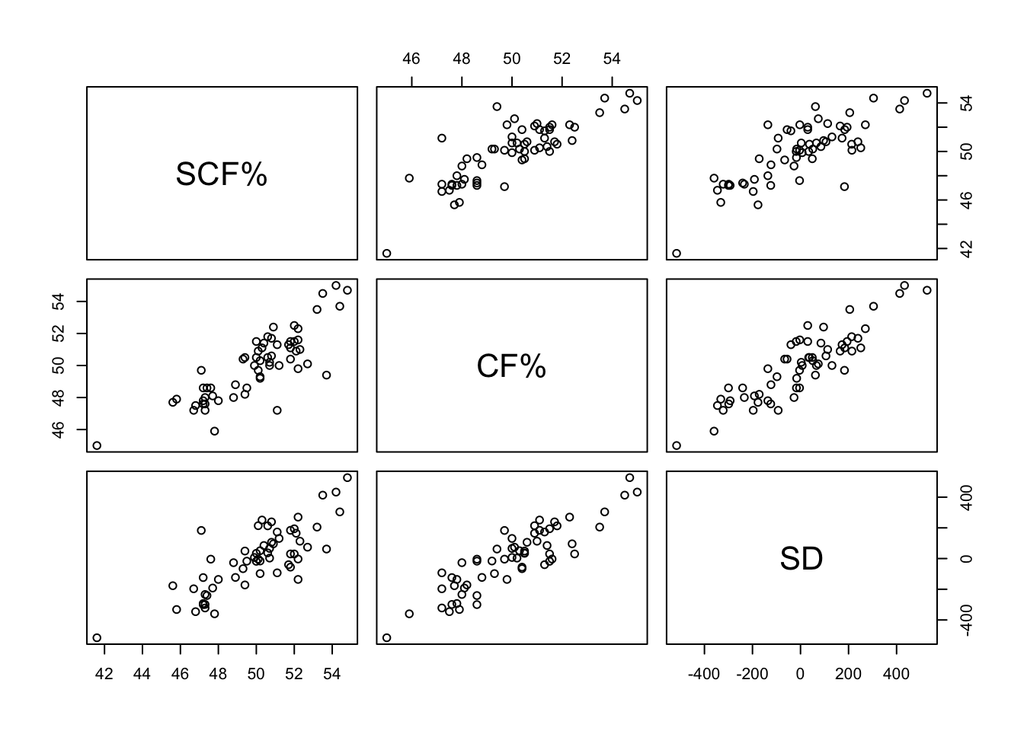

```r
pairs(~`SCF%` + `CF%` + SD, data = seasons)
```

Based on the values of VIF, SD and CF% appear to have critical levels of multi-collinearity, and one of these variables should be removed from the model. This is confirmed with the pairs plots as CF% and SD appear to be linearly correlated.

Since CF% is more significant in the parameter estimates from the stepwise output, SD will be dropped and a new model will be built.

```r
reduced_stepwise1b <- lm(data = seasons, FUTURE_PTS ~ `CF%` + `SCF%`)
summary(reduced_stepwise1b)
```

```
##
## Call:
## lm(formula = FUTURE_PTS ~ `CF%` + `SCF%`, data = seasons)
##
## Residuals:
##     Min      1Q  Median      3Q     Max
## -28.298  -7.833   1.032   5.262  30.053
##
## Coefficients:
##             Estimate Std. Error t value Pr(>|t|)
## (Intercept)  -95.747     36.913  -2.594    0.012 *
## `CF%`          1.907      1.345   1.418    0.162
## `SCF%`         1.826      1.142   1.599    0.115
## ---
## Signif. codes:  0 '***' 0.001 '**' 0.01 '*' 0.05 '.' 0.1 ' ' 1
##
## Residual standard error: 12.03 on 58 degrees of freedom
## Multiple R-squared:  0.324,  Adjusted R-squared:  0.3007
## F-statistic:  13.9 on 2 and 58 DF,  p-value: 1.169e-05
```

Based on the adjusted R-squared value from the reduced stepwise model, this model is not any better than the model with just SCF%. However, with two variables available, an interaction term can be tested.

```r
reduced_interaction <- lm(data = seasons, FUTURE_PTS ~ (`CF%` + `SCF%`)**2)
summary(reduced_interaction)
```

```
##
## Call:
## lm(formula = FUTURE_PTS ~ (`CF%` + `SCF%`)^2, data = seasons)
##
## Residuals:
##     Min      1Q  Median      3Q     Max
## -28.300  -7.875   1.139   5.208  30.057
##
## Coefficients:
##                Estimate Std. Error t value Pr(>|t|)
## (Intercept)  -1.154e+02  6.013e+02  -0.192    0.849
## `CF%`         2.317e+00  1.261e+01   0.184    0.855
## `SCF%`        2.202e+00  1.157e+01   0.190    0.850
## `CF%`:`SCF%` -7.875e-03  2.407e-01  -0.033    0.974
##
## Residual standard error: 12.14 on 57 degrees of freedom
## Multiple R-squared:  0.324,  Adjusted R-squared:  0.2885
## F-statistic: 9.108 on 3 and 57 DF,  p-value: 5.106e-05
```

From the summary output of the model with the interaction term, none of the terms are significant which means the interaction model will not be used. Since the additive model with CF% and SCF% did not perform any better than the model with SCF%, the model with SCF% is the best model at this point.

The best fitted model at this point is as follows:

```r
coefficients(model_stepwise1_team_pts$model)
```

```
## (Intercept)      `SCF%`
##  -68.072314    3.179121
```

```r
summary(model_stepwise1_team_pts$model)$r.squared
```

```
## [1] 0.3006051
```

$$\widehat{Points_{future{}}} = -68.1 + 3.2 * SCF\%$$

Based on this model, with every one percent increase in SCF%, a teams next season points total will increase by ~3.2.

### Model with all available variables

The statistics that will be used in the second full additive model are:

- AvAge
- W
- L
- OL
- PTS
- GF
- GA
- GD
- SOW
- SOL
- SRS
- SOS
- TG/G
- EVGF
- EVGA
- PD
- SD
- PDO
- CF%
- FF%
- xGF
- xGA
- SCF%
- HDF%

The second full additive model will be built with the `lm()` function using the seasons dataset from hockey-reference.com. The individual coefficients test will be used to test the significance of each of the variables.

```r
model_full2_team_pts <- lm(data = seasons,
                          FUTURE_PTS ~ AvAge + W + L + OL + PTS + GF + GA + GD + SOW + SOL + SRS +
                            SOS + `TG/G` + EVGF + EVGA + PD + SD + PDO + `CF%` + `FF%` + xGF + xGA +
                            `SCF%` + `HDF%`)
summary(model_full2_team_pts)
```

```
##
## Call:
## lm(formula = FUTURE_PTS ~ AvAge + W + L + OL + PTS + GF + GA +
##     GD + SOW + SOL + SRS + SOS + `TG/G` + EVGF + EVGA + PD +
##     SD + PDO + `CF%` + `FF%` + xGF + xGA + `SCF%` + `HDF%`, data = seasons)
##
## Residuals:
##      Min       1Q   Median       3Q      Max
## -19.5838  -6.1337  -0.4094   4.5808  23.5324
##
## Coefficients: (3 not defined because of singularities)
##               Estimate Std. Error t value Pr(>|t|)
## (Intercept) -3.670e+02  6.680e+02  -0.549   0.5859
## AvAge       -1.996e+00  1.634e+00  -1.221   0.2294
## W            2.787e-03  1.025e+00   0.003   0.9978
## L           -5.126e-02  8.401e-01  -0.061   0.9517
## OL                  NA         NA      NA       NA
## PTS                 NA         NA      NA       NA
## GF          -1.654e+01  8.952e+00  -1.848   0.0722 .
## GA          -1.892e+01  7.967e+00  -2.375   0.0225 *
## GD                  NA         NA      NA       NA
## SOW          1.397e+00  5.075e+00   0.275   0.7845
## SOL         -9.760e-01  5.086e+00  -0.192   0.8488
## SRS         -1.093e+02  4.120e+02  -0.265   0.7922
## SOS          9.628e+01  4.004e+02   0.240   0.8112
## `TG/G`       1.485e+03  5.624e+02   2.640   0.0119 *
## EVGF        -3.256e-02  3.470e-01  -0.094   0.9257
## EVGA        -4.542e-01  3.604e-01  -1.260   0.2150
## PD          -2.468e+00  2.506e+00  -0.985   0.3306
## SD          -1.780e-02  2.884e-02  -0.617   0.5406
## PDO          1.274e+00  6.200e+00   0.206   0.8382
## `CF%`        3.069e+00  2.644e+00   1.161   0.2528
## `FF%`        5.428e-01  3.764e+00   0.144   0.8861
## xGF         -5.293e-01  3.192e-01  -1.658   0.1053
## xGA          1.514e-01  3.249e-01   0.466   0.6438
## `SCF%`       2.899e+00  2.107e+00   1.376   0.1768
## `HDF%`       7.836e-01  8.731e-01   0.897   0.3750
## ---
## Signif. codes:  0 '***' 0.001 '**' 0.01 '*' 0.05 '.' 0.1 ' ' 1
##
## Residual standard error: 10.7 on 39 degrees of freedom
## Multiple R-squared:  0.6406, Adjusted R-squared:  0.4471
## F-statistic:  3.31 on 21 and 39 DF,  p-value: 0.0006019
```

From here, the stepwise regression procedure will be used to test all the available variables to see if the significant terms from the individual coefficients test is consistent with the stepwise procedure. A p-value entry limit of 0.05 and p-value exit limit of 0.3 will be used for this stepwise model.

```r
model_stepwise2_team_pts <- ols_step_both_p(model_full2_team_pts, pent = 0.05, prem = 0.3)
```

```
## Stepwise Selection Method
## ---------------------------
##
## Candidate Terms:
##
## 1. AvAge
## 2. W
## 3. L
## 4. OL
## 5. PTS
## 6. GF
## 7. GA
## 8. GD
## 9. SOW
## 10. SOL
## 11. SRS
## 12. SOS
## 13. `TG/G`
## 14. EVGF
## 15. EVGA
## 16. PD
## 17. SD
## 18. PDO
## 19. `CF%`
## 20. `FF%`
## 21. xGF
## 22. xGA
## 23. `SCF%`
## 24. `HDF%`
##
## We are selecting variables based on p value...
##
## Variables Entered/Removed:
##
## - `SCF%` added
## - `TG/G` added
## - xGF added
## - `CF%` added
##
## No more variables to be added/removed.
```

[output cut: 21 more lines]

```
## Regression     5639.585         4       1409.896    11.631    0.0000
## Residual       6788.087        56        121.216
## Total         12427.672        60
## ---------------------------------------------------------------------
##
##                                      Parameter Estimates
## ----------------------------------------------------------------------------------------------
##       model        Beta    Std. Error    Std. Beta      t        Sig        lower       upper
## ----------------------------------------------------------------------------------------------
## (Intercept)    -208.858        46.299                 -4.511    0.000    -301.606    -116.109
##      `SCF%`       2.209         1.203        0.381     1.836    0.072      -0.201       4.620
##      `TG/G`      18.174         4.994        0.462     3.639    0.001       8.171      28.178
##         xGF      -0.340         0.148       -0.346    -2.301    0.025      -0.635      -0.044
##       `CF%`       2.888         1.292        0.423     2.235    0.029       0.299       5.476
## ----------------------------------------------------------------------------------------------
```

From the stepwise regression procedure, the following variables appear to be significant:

- SCF%
- TG/G
- xGF
- CF%

In order to ensure that these variables are independent, multi-collinearity will be tested using the `vif()` function from the `car` package to calculate the variance inflation factor (VIF) and the `pairs()` function for visual identification.

```r
vif(model_stepwise2_team_pts$model)
```

```
##   `SCF%`   `TG/G`      xGF    `CF%`
## 4.415788 1.655211 2.315742 3.668395
```

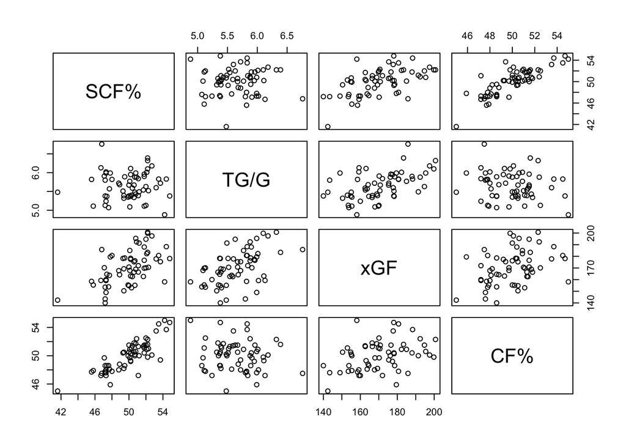

```r
pairs(~`SCF%` + `TG/G` + xGF + `CF%`, data = seasons)
```

Based on the values of VIF, SCF% and CF% appear to have moderate levels of multi-collinearity, bordering on significant. From the pairs visualization, SCF% and CF% appears to be linearly correlated.

Since CF% is more significant in the parameter estimates from the stepwise output, but SCF% was the first variable chosen in the stepwise regression procedure, both variables will be dropped independently and two models will be tested.

```r
model_stepwise2_reduced_team_pts_a <- lm(data = seasons, FUTURE_PTS ~ `TG/G` + xGF + `CF%`)
# Adjusted R-squared of model without SCF%
summary(model_stepwise2_reduced_team_pts_a)$adj.r.squared
```

```
## [1] 0.39044
```

```r
model_stepwise2_reduced_team_pts_b <- lm(data = seasons, FUTURE_PTS ~ `TG/G` + xGF + `SCF%`)
# Adjusted R-squared of model without CF%
summary(model_stepwise2_reduced_team_pts_b)$adj.r.squared
```

```
## [1] 0.3737718
```

Since the adjusted R squared value is higher in the model without SCF%, this will be the model that is used going forward. As there has been a change to the model, the individual coefficients test will be used to ensure all variables continue to be significant.

```r
model_stepwise2_reduced_team_pts <- lm(data = seasons, FUTURE_PTS ~ `TG/G` + xGF + `CF%`)
summary(model_stepwise2_reduced_team_pts)
```

```
##
## Call:
## lm(formula = FUTURE_PTS ~ `TG/G` + xGF + `CF%`, data = seasons)
##
## Residuals:
##      Min       1Q   Median       3Q      Max
## -24.4354  -6.8007  -0.1749   7.0765  22.1030
##
## Coefficients:
##              Estimate Std. Error t value Pr(>|t|)
## (Intercept) -208.4509    47.2515  -4.412 4.61e-05 ***
## `TG/G`        17.6714     5.0889   3.473 0.000991 ***
## xGF           -0.2219     0.1356  -1.636 0.107384
## `CF%`          4.7437     0.8215   5.775 3.36e-07 ***
## ---
## Signif. codes:  0 '***' 0.001 '**' 0.01 '*' 0.05 '.' 0.1 ' ' 1
##
## Residual standard error: 11.24 on 57 degrees of freedom
## Multiple R-squared:  0.4209, Adjusted R-squared:  0.3904
## F-statistic: 13.81 on 3 and 57 DF,  p-value: 7.007e-07
```

Since the p-value of xGF is higher than 0.05, it will be removed from the reduced model.

```r
model_stepwise2_reduced_team_pts <- lm(data = seasons, FUTURE_PTS ~ `TG/G` + `CF%`)
summary(model_stepwise2_reduced_team_pts)
```

```
##
## Call:
## lm(formula = FUTURE_PTS ~ `TG/G` + `CF%`, data = seasons)
##
## Residuals:
##      Min       1Q   Median       3Q      Max
## -23.3165  -7.2437  -0.1601   5.9414  21.6286
##
## Coefficients:
##              Estimate Std. Error t value Pr(>|t|)
## (Intercept) -181.6257    44.9504  -4.041 0.000159 ***
## `TG/G`        12.5383     4.0638   3.085 0.003113 **
## `CF%`          4.0309     0.7064   5.707 4.13e-07 ***
## ---
## Signif. codes:  0 '***' 0.001 '**' 0.01 '*' 0.05 '.' 0.1 ' ' 1
##
## Residual standard error: 11.4 on 58 degrees of freedom
## Multiple R-squared:  0.3937, Adjusted R-squared:  0.3728
## F-statistic: 18.83 on 2 and 58 DF,  p-value: 4.981e-07
```

Two variables remain in the best fitted model which means we have the opportunity to test an interaction term.

```r
model_stepwise2_interact_team_pts <- lm(data = seasons, FUTURE_PTS ~ (`TG/G` + `CF%`)**2)
summary(model_stepwise2_interact_team_pts)
```

```
##
## Call:
## lm(formula = FUTURE_PTS ~ (`TG/G` + `CF%`)^2, data = seasons)
##
## Residuals:
##     Min      1Q  Median      3Q     Max
## -23.186  -7.299  -0.161   5.958  21.500
##
## Coefficients:
##               Estimate Std. Error t value Pr(>|t|)
## (Intercept)  -149.7448   492.3278  -0.304    0.762
## `TG/G`          6.8607    87.4011   0.078    0.938
## `CF%`           3.3923     9.8450   0.345    0.732
## `TG/G`:`CF%`    0.1138     1.7494   0.065    0.948
##
## Residual standard error: 11.5 on 57 degrees of freedom
## Multiple R-squared:  0.3938, Adjusted R-squared:  0.3619
## F-statistic: 12.34 on 3 and 57 DF,  p-value: 2.507e-06
```

Since neither of the interaction terms are significant, the best fitted model is as follows:

```r
coefficients(model_stepwise2_reduced_team_pts)
```

```
## (Intercept)      `TG/G`       `CF%`
## -181.625735   12.538322    4.030869
```

$$\widehat{Points_{future}} = -181.63 + 12.5 * TG/G + 4.0 * CF\%$$

Based on this model, with every one percent increase in CF%, a teams next season points total will increase by ~4. Similarly, with every one unit increase in TG/G, a teams next season points total will increase by ~12.5.

In order to ensure that this model is acceptable, a few additional assumptions will be tested:

- Linearity
- Equal variance
- Normality
- Outlier

The linearity and equal variance assumptions will be tested by plotting the fitted versus the residual values on a scatter plot and visually determining if a trend can be observed.

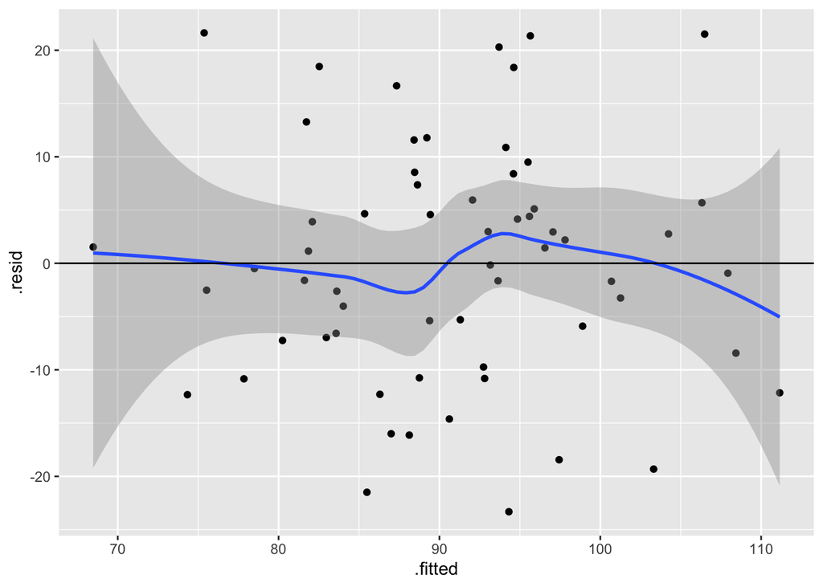

```r
ggplot(model_stepwise2_reduced_team_pts, aes(x=.fitted, y=.resid)) +
  geom_point() +
  geom_smooth() +
  geom_hline(yintercept = 0)
```

Since the plot above displays no observable pattern between the residuals and the fitted values of the model, the linearity and equal variance assumptions hold. Additionally, the Breusch-Pagan test can be used to confirm the equal variance assumption quantitatively.

```r
bptest(model_stepwise2_reduced_team_pts)
```

```
##
##  studentized Breusch-Pagan test
##
## data:  model_stepwise2_reduced_team_pts
## BP = 0.1035, df = 2, p-value = 0.9496
```

Since the p-value from the Breusch-Pagan test is greater than 0.05, we can confirm that heteroscedasticity is not present.

The normality assumption will be tested using the Shapiro-Wilk test.

```r
shapiro.test(residuals(model_stepwise2_reduced_team_pts))
```

```
##
##  Shapiro-Wilk normality test
##
## data:  residuals(model_stepwise2_reduced_team_pts)
## W = 0.98268, p-value = 0.5406
```

Since the p-value from the Shapiro-Wilk test is greater than 0.05, we can say that the sample data are significantly normally distributed, thus confirming the normality assumption.

Lastly, the outlier assumption will be tested using the leverage points methodology.

```r
lev <- hatvalues(model_stepwise2_reduced_team_pts)
p <- length(coef(model_stepwise2_reduced_team_pts))
n <- nrow(seasons)
outlier <- lev[lev > (3 * p / n)]
outlier
```

```
##        27        38
## 0.1640350 0.1762808
```

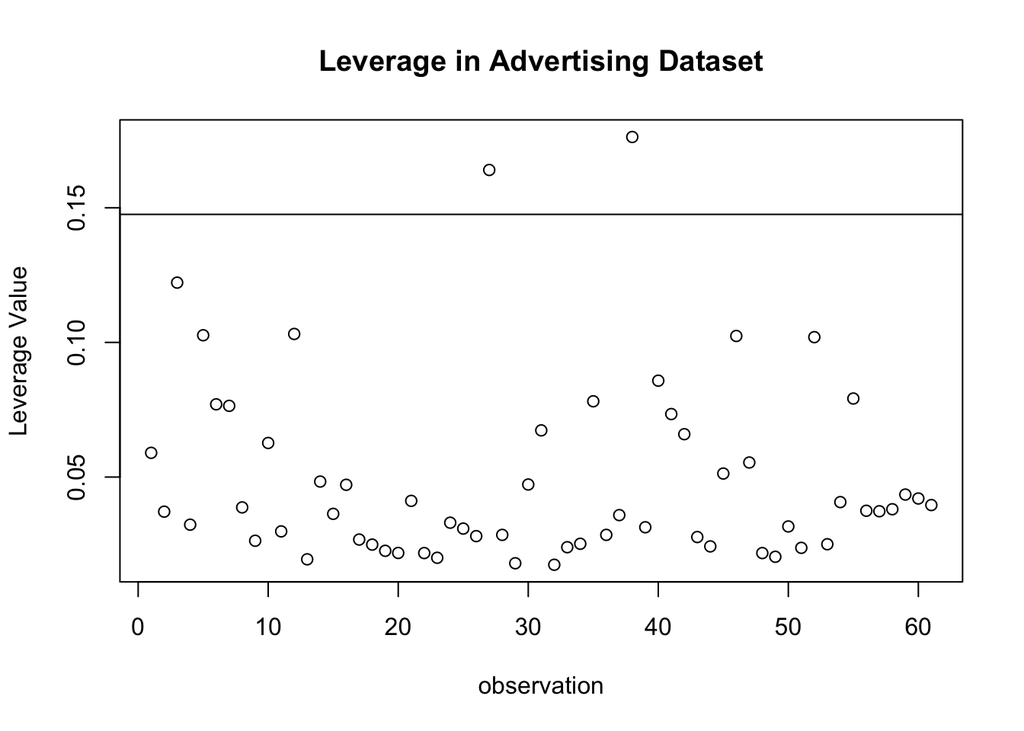

```r
plot(rownames(seasons), lev, main = "Leverage in Advertising Dataset",
     xlab="observation",
     ylab = "Leverage Value")
abline(h = 3 *p/n, lty = 1)
```

Since there are two outliers that affect the model, a new model will be tested without these outliers.

```r
final_model_no_outliers <- lm(data = seasons[-c(27, 38),], FUTURE_PTS ~ `TG/G` + `CF%`)
summary(final_model_no_outliers)
```

```
##
## Call:
## lm(formula = FUTURE_PTS ~ `TG/G` + `CF%`, data = seasons[-c(27,
##     38), ])
##
## Residuals:
##     Min      1Q  Median      3Q     Max
## -24.616  -7.415   0.858   5.556  22.737
##
## Coefficients:
##              Estimate Std. Error t value Pr(>|t|)
## (Intercept) -178.7886    45.8873  -3.896 0.000263 ***
## `TG/G`        10.6470     4.6153   2.307 0.024781 *
## `CF%`          4.1864     0.7513   5.572 7.46e-07 ***
## ---
## Signif. codes:  0 '***' 0.001 '**' 0.01 '*' 0.05 '.' 0.1 ' ' 1
##
## Residual standard error: 11.51 on 56 degrees of freedom
## Multiple R-squared:  0.3925, Adjusted R-squared:  0.3708
## F-statistic: 18.09 on 2 and 56 DF,  p-value: 8.678e-07
```

Now that the outliers have been removed and all other assumptions have been tested, the final best fitted model becomes:

$$\widehat{Points_{future}} = -178.8 + 10.6 * TG/G + 4.2 * CF\%$$

Based on this model, with every one percent increase in CF%, a teams next season points total will increase by ~4.2. Similarly, with every one unit increase in TG/G, a teams next season points total will increase by ~10.6.

# Conclusion

## Multiple Linear Regression Model for Predicting Team’s Points Totals

The best fitted multiple linear regression model for predicting team’s points totals is as follows:

$$\widehat{Points_{future}} = -178.8 + 10.6 * TG/G + 4.2 * CF\%$$